# Bonus Code: Day 5

Author

Constantin Manuel Bosancianu

Published

August 4, 2017

# 1 Introduction

I show here a small implementation of code for multilevel models. The data comes from the *World Values Surveys* series.

```r
library(pacman)
p_load(readstata13, tidyverse, foreign, texreg, knitr, kableExtra,
       magrittr, ggthemes, effects, arm, lmtest, ggthemes, interplot)
```

```r
df_wvs <- readRDS(file = "../02-data/19-wvs.rds")

df_wvs %>%
    glimpse()
```

```
Rows: 86,271
Columns: 20
$ country  <chr> "Algeria", "Algeria", "Algeria", "Algeria", "Algeria", "Alger…
$ year     <dbl> 2013, 2013, 2013, 2013, 2013, 2013, 2013, 2013, 2013, 2013, 2…
$ postmt12 <dbl> 3, 2, 3, 2, 3, 3, 3, 2, 3, 4, 4, NA, 1, 0, 2, 2, NA, 2, 2, 3,…
$ postmat4 <dbl> 3, 2, 2, 1, 2, 2, 3, 2, 2, 3, 3, NA, 1, 1, 2, 2, 2, 2, 1, 2, …
$ autonom  <dbl> -1, 0, 0, 1, 2, 0, -1, 2, -1, 1, 1, 1, 0, -1, -1, -1, -2, 0, …
$ sacsec   <dbl> 0.359722, 0.512500, 0.207222, 0.260472, 0.513056, 0.276945, 0…
$ age      <dbl> 4, 7, 44, 8, 15, 24, 38, 0, 53, 15, 56, 36, 15, 16, 2, 8, 39,…
$ income   <dbl> 1, 1, 4, 3, 1, 6, 1, 4, 4, 4, 3, 3, 1, 1, 6, 2, 3, 3, 3, 2, 3…
$ gender   <dbl> 1, 0, 1, 0, 1, 0, 0, 1, 0, 0, 1, 1, 1, 0, 1, 0, 0, 1, 1, 1, 0…
$ educat   <dbl> 8, 5, 0, 6, 0, 6, 2, 2, 0, 2, 0, 0, 2, 6, 6, 2, 0, 0, 7, 1, 1…
$ unemp    <dbl> 0, 1, 0, 0, 0, 0, 0, 0, 0, 0, 0, 0, 0, 0, 0, 1, 0, 0, 0, 0, 0…
$ polity2  <dbl> 2, 2, 2, 2, 2, 2, 2, 2, 2, 2, 2, 2, 2, 2, 2, 2, 2, 2, 2, 2, 2…
$ gdpc     <dbl> 3212.105, 3212.105, 3212.105, 3212.105, 3212.105, 3212.105, 3…
$ ginisolt <dbl> NA, NA, NA, NA, NA, NA, NA, NA, NA, NA, NA, NA, NA, NA, NA, N…
$ obedeman <dbl> 3.60000, 2.76667, 2.62500, 2.91667, 5.14306, 4.22222, 2.90593…
$ polint   <dbl> 0, 2, 2, 0, 2, 1, 2, 2, 2, 1, 1, 2, 2, 2, 3, 0, 0, 0, 1, 0, 1…
$ gcb_ppol <chr> "3.831622", "3.831622", "3.831622", "3.831622", "3.831622", "…
$ ti_cpi   <chr> "3.600000", "3.600000", "3.600000", "3.600000", "3.600000", "…
$ une_eet  <chr> "26.97261", "26.97261", "26.97261", "26.97261", "26.97261", "…
$ r_elf85  <chr> "0.299", "0.299", "0.299", "0.299", "0.299", "0.299", "0.299"…
```

The outcome used in this analysis is an index of obedience-vs-emancipative values.[^1]

<sup>1</sup> Detailed information on how this index was created from variables available in the WVS can be found [here](https://www.worldvaluessurvey.org/WVSContents.jsp?CMSID=welzelidx&CMSID=welzelidx).

# 2 Pooling vs. no pooling approach

```r
model.1 <- lm(obedeman ~ age + income + gender + educat, data = df_wvs)
model.2 <- lm(obedeman ~ age + income + gender + educat + as.factor(country),
              data = df_wvs)

htmlreg(list(model.1, model.2),
        digits = 3,
        custom.model.names = c("No dummies", "Dummies (ref. Algeria)"))
```

Statistical models

|  | No dummies | Dummies (ref. Algeria) |
| --- | --- | --- |
| (Intercept) | 2.882*** | 2.802*** |
|  | (0.020) | (0.041) |
| age | 0.007*** | -0.010*** |
|  | (0.000) | (0.000) |
| income | 0.005 | 0.036*** |
|  | (0.003) | (0.002) |
| gender | 0.274*** | 0.262*** |
|  | (0.012) | (0.009) |
| educat | 0.181*** | 0.102*** |
|  | (0.003) | (0.002) |
| as.factor(country)Argentina |  | 1.969*** |
|  |  | (0.058) |
| as.factor(country)Armenia |  | -0.479*** |
|  |  | (0.056) |
| as.factor(country)Australia |  | 2.667*** |
|  |  | (0.057) |
| as.factor(country)Azerbaijan |  | -0.096 |
|  |  | (0.057) |
| as.factor(country)Bahrain |  | 0.439*** |
|  |  | (0.058) |
| as.factor(country)Belarus |  | 0.535*** |
|  |  | (0.052) |
| as.factor(country)Brazil |  | 1.460*** |
|  |  | (0.052) |
| as.factor(country)Chile |  | 1.832*** |
|  |  | (0.059) |
| as.factor(country)China |  | 0.643*** |
|  |  | (0.049) |
| as.factor(country)Colombia |  | 0.833*** |
|  |  | (0.052) |

[output cut: 101 more lines]

***p < 0.001; **p < 0.01; *p < 0.05

```r
bptest(model.1)
```

```
    studentized Breusch-Pagan test

data:  model.1
BP = 716.76, df = 4, p-value < 2.2e-16
```

```r
rm(model.1, model.2)
```

# 3 Country-by-country differences

```r
model31 <- lm(obedeman ~ age + income + gender + educat, data = filter(df_wvs,
              country == "Algeria"))
model32 <- lm(obedeman ~ age + income + gender + educat, data = filter(df_wvs,
              country == "Argentina"))
model33 <- lm(obedeman ~ age + income + gender + educat, data = filter(df_wvs,
              country == "Armenia"))
model34 <- lm(obedeman ~ age + income + gender + educat, data = filter(df_wvs,
              country == "Australia"))
model35 <- lm(obedeman ~ age + income + gender + educat, data = filter(df_wvs,
              country == "Azerbaijan"))

htmlreg(list(model31, model32, model33, model34, model35),
        digits = 3,
        custom.model.names = c("Algeria", "Argentina", "Armenia",
                               "Australia", "Azerbaijan"),
        custom.coef.names = c("(Intercept)", "Age", "Income",
                              "Gender (female)", "Education"))
```

[output not shown]

[output cut: 69 more lines]

[output not shown]

```r
rm(model31, model32, model33, model34, model35)
```

# 4 Multilevel specification

Recoding done to improve the convergence. It won’t affect the significance of the coefficients, although the interpretation of the slopes changes a bit, as now units are expressed in 1000s (in the case of GDP per capita).

## 4.1 Initial specification

```r
df_wvs %<>%
    mutate(gdpc = gdpc / 1000,
           ginisolt = ginisolt / 10,
           age = age / 10)
```

```r
model.1 <- lmer(obedeman ~ age + income + educat + gender + gdpc +
                    ginisolt + polity2 + (1 | country),
                data = df_wvs,
                na.action = na.omit)
summary(model.1)
```

```
Linear mixed model fit by REML ['lmerMod']
Formula: obedeman ~ age + income + educat + gender + gdpc + ginisolt +
    polity2 + (1 | country)
   Data: df_wvs

REML criterion at convergence: 144534.4

Scaled residuals:
    Min      1Q  Median      3Q     Max
-4.3217 -0.6807 -0.0132  0.6654  4.3562

Random effects:
 Groups   Name        Variance Std.Dev.
 country  (Intercept) 0.4965   0.7046
 Residual             1.8735   1.3688
Number of obs: 41641, groups:  country, 30

Fixed effects:
             Estimate Std. Error t value
(Intercept)  3.123458   0.837972   3.727
age         -0.118320   0.004327 -27.346
income       0.031231   0.003489   8.952
educat       0.137276   0.003540  38.780
gender       0.241985   0.013498  17.927
gdpc         0.045152   0.010479   4.309
ginisolt    -0.071788   0.198074  -0.362
polity2      0.058341   0.026747   2.181

Correlation of Fixed Effects:
         (Intr) age    income educat gender gdpc   ginslt
age      -0.025
income   -0.011  0.050
educat   -0.029  0.268 -0.242
gender   -0.012 -0.002  0.039  0.027
gdpc     -0.511 -0.007 -0.002 -0.006  0.001
ginisolt -0.961  0.007 -0.001  0.009  0.002  0.425
polity2  -0.203 -0.001  0.001  0.004  0.001 -0.283  0.057
```

You can easily extract quantities of interest.

```r
fixef(model.1)
```

```
(Intercept)         age      income      educat      gender        gdpc
 3.12345783 -0.11831972  0.03123079  0.13727625  0.24198477  0.04515205
   ginisolt     polity2
-0.07178839  0.05834127
```

```r
ranef(model.1)
```

```
$country
              (Intercept)
Argentina     -0.30780253
Armenia       -1.03992125
Australia      0.21694652
Belarus        0.47661498
Chile          0.78478828
China          0.88687496
Colombia       0.16364999
Cyprus        -0.75299541
Estonia        0.18254617
Japan         -0.66013001
Kazakhstan     0.04400715
Kyrgyzstan    -0.81929522
Malaysia      -0.47070948
Mexico         0.44766406
Netherlands    0.29015040
New Zealand    0.31614162
Nigeria       -0.93251636
Peru           0.23117717
Philippines    0.11009413
Poland         0.15859642
Romania       -0.07495858
Russia        -0.08582156
Singapore     -0.60600470
Slovenia       1.08902165
South Korea   -0.64489377
Spain          0.65093274
Sweden         1.04861678
Turkey        -1.00086811
United States -0.89068562
Uruguay        1.18877958

with conditional variances for "country"
```

```r
se.fixef(model.1)
```

```
(Intercept)         age      income      educat      gender        gdpc
0.837972059 0.004326816 0.003488857 0.003539853 0.013498234 0.010478789
   ginisolt     polity2
0.198073955 0.026746562
```

```r
se.ranef(model.1)
```

```
$country
              (Intercept)
Argentina      0.04372852
Armenia        0.04142489
Australia      0.04267443
Belarus        0.03507600
Chile          0.04525545
China          0.03105393
Colombia       0.03554596
Cyprus         0.04350706
Estonia        0.03523836
Japan          0.03221932
Kazakhstan     0.03529689
Kyrgyzstan     0.03561810
Malaysia       0.03792217
Mexico         0.03115028
Netherlands    0.03430734
New Zealand    0.05091274
Nigeria        0.03260089
Peru           0.03990076
Philippines    0.03946715
Poland         0.04501010
Romania        0.03592347
Russia         0.02795852
Singapore      0.03119070
Slovenia       0.04294664
South Korea    0.03953294
Spain          0.04204565
Sweden         0.04043694
Turkey         0.03453591
United States  0.02938465
Uruguay        0.04425100
```

## 4.2 Centering predictors

Needed at all times, for both level 1 and level 2 predictors.[^2] Especially important here, given that we’re investigating an interaction.

<sup>2</sup> See why [here](https://citeseerx.ist.psu.edu/document?repid=rep1&type=pdf&doi=fe8d7d6a61d067491d222af2abd836ae23672ef3).

Though we could easily use a custom function for this, `arm` comes already with a `rescale()` function for exactly this purpose.

```r
df_wvs %<>%
    group_by(country) %>%
    mutate(educ_cwc = arm::rescale(educat),
           age_cwc = arm::rescale(age),
           inc_cwc = arm::rescale(income),
           gen_cwc = arm::rescale(gender)) %>%
    ungroup() %>%
    dplyr::select(-c(educat, age, income, gender))
```

```r
df_agg <- df_wvs %>%
    group_by(country) %>%
    summarise(gdpc = mean(gdpc, na.rm = TRUE),
              gini = mean(ginisolt, na.rm = TRUE),
              polity = mean(polity2, na.rm = TRUE)) %>%
    ungroup() %>%
    mutate(gdpc_cgm = arm::rescale(gdpc),
           gini_cgm = arm::rescale(gini),
           polity_cgm = arm::rescale(polity)) %>%
    dplyr::select(-c(gdpc, gini, polity))

# Merge the two data sets
df_wvs <- left_join(df_wvs, df_agg,
                    by = "country") %>%
    dplyr::select(-c(gdpc, ginisolt, polity2))
```

## 4.3 Cross-level interactions

Although it’s not immediately visible from this form of the model, here GDP/capita is added as a predictor of the slope of education, leading to the cross-level interaction you see here.

```r
model.2 <- lmer(obedeman ~ age_cwc + inc_cwc + educ_cwc + gen_cwc +
                    gdpc_cgm + gini_cgm + polity_cgm + educ_cwc * gdpc_cgm +
                    (1 + educ_cwc | country),
                data = df_wvs,
                na.action = na.omit)
summary(model.2)
```

```
Linear mixed model fit by REML ['lmerMod']
Formula: obedeman ~ age_cwc + inc_cwc + educ_cwc + gen_cwc + gdpc_cgm +
    gini_cgm + polity_cgm + educ_cwc * gdpc_cgm + (1 + educ_cwc |      country)
   Data: df_wvs

REML criterion at convergence: 144035

Scaled residuals:
    Min      1Q  Median      3Q     Max
-4.5209 -0.6793 -0.0158  0.6686  4.3680

Random effects:
 Groups   Name        Variance Std.Dev. Corr
 country  (Intercept) 0.4567   0.6758
          educ_cwc    0.1032   0.3212   0.59
 Residual             1.8487   1.3597
Number of obs: 41641, groups:  country, 30

Fixed effects:
                  Estimate Std. Error t value
(Intercept)        4.42020    0.13106  33.726
age_cwc           -0.37919    0.01422 -26.662
inc_cwc            0.09483    0.01392   6.814
educ_cwc           0.58384    0.06237   9.361
gen_cwc            0.24085    0.01345  17.909
gdpc_cgm           1.52937    0.28317   5.401
gini_cgm          -0.10521    0.23009  -0.457
polity_cgm         0.11050    0.25782   0.429
educ_cwc:gdpc_cgm  0.23247    0.12318   1.887

Correlation of Fixed Effects:
            (Intr) ag_cwc inc_cw edc_cw gn_cwc gdpc_c gn_cgm plty_c
age_cwc      0.000
inc_cwc     -0.002  0.051
educ_cwc     0.556  0.064 -0.056
gen_cwc      0.001  0.006  0.039  0.005
gdpc_cgm    -0.208 -0.002 -0.001 -0.123 -0.001
gini_cgm    -0.132 -0.005  0.002  0.001 -0.005  0.365
polity_cgm  -0.201  0.002  0.007 -0.005  0.000 -0.242  0.058
edc_cwc:gd_ -0.136 -0.005 -0.006 -0.240 -0.001  0.513  0.001  0.001
```

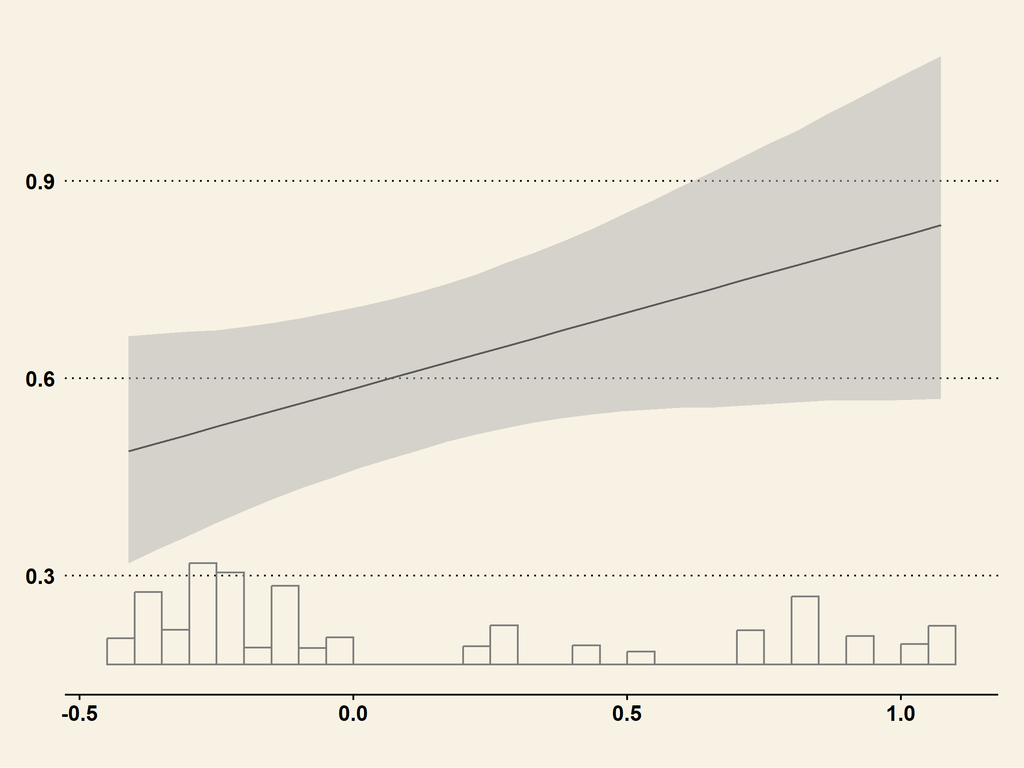

```r
interplot(model.2,
          var1 = "educ_cwc",
          var2 = "gdpc_cgm",
          hist = TRUE) +
    xlab("Centered GDP per capita") +
    ylab("Effect of education on obedience/emancipation") +
    theme_wsj()
```

# 5 Package versions